# CHronoZ | Rolling correlation

## Summary

The saved run estimates **351 pair histories** using trailing **60-month windows** with at least **48 paired observations**. There are **189,286 defined estimates**. All **351 pairs** are available for the latest window, **2021-09 to 2026-08**. Independent checks reconciled **1,053 windows** with direct calculations.

Charts and tables use full dataset titles. Missing months remain missing. This summary describes the saved run; the final summary cell recomputes the results when inputs or parameters change.

## Context & Methods

How stable are contemporaneous monthly-change associations through time?

### Assumptions and scope

- Native monthly series only, selected by both expected and inferred frequency. Weekly and quarterly exclusions are displayed.
- Use the same explicit percentage-change / first-difference registry as the initial correlation notebook. Rates use percentage-point changes; hours use hour changes.
- Changes require consecutive calendar months. Dropped observations remain gaps; a September-November move is never treated as one month.
- No re-cleaning, interpolation, filling, frequency conversion, model training, or automatic variable removal.
- Correlation is descriptive co-movement. It does not establish causality or predictive value. No release-calendar/vintage data is available, so observation dates are not information-availability dates.
- Pearson correlations use trailing 60-calendar-month windows, including the labeled end month, with >=48 paired observations. No future observations enter a window.
- The calendar grid contains NaNs for absent months, never fabricated values. Windows begin only after 60 calendar months have elapsed since the first paired observation. Constant windows are undefined.
- Adjacent windows overlap heavily; paths and observed ranges are descriptive and are not independent statistical tests. Four illustrative pairs are pre-specified rather than selected by their strongest full-sample correlations.

**Inputs:** `data/cleaned/series_metadata.csv`, the referenced cleaned series, and `data/audit/data_cleaning_audit.csv`. All inputs are read directly; this notebook does not depend on another notebook being run. **Outputs:** `outputs/rolling_correlation/`. Full titles are used in reports; source IDs remain internal. **Environment:** Python with `requirements-notebook.txt`; Restart Kernel and Run All from the project or notebook folder.

### Setup and editable parameters

```
Inputs: C:\Users\HYPE AMD\Desktop\CHronoZ-Economic-Modelling\data\cleaned
Outputs: C:\Users\HYPE AMD\Desktop\CHronoZ-Economic-Modelling\outputs\rolling_correlation
Minimum pairwise sample: 60 months
```

## Data

### Select monthly inputs and disclose exclusions

```
Monthly variables selected: 27
```

| Dataset | Expected frequency | Inferred frequency | Reason |
| --- | --- | --- | --- |
| Initial Claims | weekly | weekly | Native weekly; outside monthly scope |
| SLOOS: Banks Tightening C&I Lending Standards | quarterly | quarterly | Native quarterly; outside monthly scope |
| SLOOS: Stronger Demand for C&I Loans | quarterly | quarterly | Native quarterly; outside monthly scope |
| Delinquency Rate on Business Loans | quarterly | quarterly | Native quarterly; outside monthly scope |
| Reserve Balances with Federal Reserve Banks | weekly | weekly | Native weekly; outside monthly scope |
| Federal Reserve Total Assets | weekly | weekly | Native weekly; outside monthly scope |
| Real Exports of Goods and Services | quarterly | quarterly | Native quarterly; outside monthly scope |
| Real Imports of Goods and Services | quarterly | quarterly | Native quarterly; outside monthly scope |
| Nonfarm Business Sector Labor Productivity | quarterly | quarterly | Native quarterly; outside monthly scope |

```
Existing cleaning warnings (retained, not repaired here):
```

| Dataset | Warning |
| --- | --- |
| Real Retail & Food Services Sales | missing_value_rows_removed=1; Suspicious gaps=1 |
| Unemployment Rate | missing_value_rows_removed=1; Suspicious gaps=1 |
| Labor Force Participation Rate | missing_value_rows_removed=1; Suspicious gaps=1 |
| CPI All Items | missing_value_rows_removed=1; Suspicious gaps=1 |
| Core CPI | missing_value_rows_removed=1; Suspicious gaps=1 |

### Load and validate cleaned series

```
Outer join: 1,364 observed dates x 27 monthly series
Alignment NaNs mean no observed value on that date; no values were filled.
```

### Native data coverage

| Dataset | Start date | End date | Observations |
| --- | --- | --- | --- |
| Industrial Production | 1919-01-01 00:00:00 | 2026-07-01 00:00:00 | 1291 |
| Manufacturing Production | 1972-01-01 00:00:00 | 2026-07-01 00:00:00 | 655 |
| Real Personal Consumption Expenditure | 2007-01-01 00:00:00 | 2026-07-01 00:00:00 | 235 |
| Real Personal Income excluding transfers | 1959-01-01 00:00:00 | 2026-07-01 00:00:00 | 811 |
| Real Personal Income | 1959-01-01 00:00:00 | 2026-07-01 00:00:00 | 811 |
| Real Retail & Food Services Sales | 1992-01-01 00:00:00 | 2026-08-01 00:00:00 | 415 |
| Housing Starts | 1959-01-01 00:00:00 | 2026-08-01 00:00:00 | 812 |
| Building Permits | 1960-01-01 00:00:00 | 2026-08-01 00:00:00 | 800 |
| Nonfarm Payroll Employment | 1939-01-01 00:00:00 | 2026-08-01 00:00:00 | 1052 |
| Unemployment Rate | 1948-01-01 00:00:00 | 2026-08-01 00:00:00 | 943 |
| Average Weekly Hours — Total Private | 2006-03-01 00:00:00 | 2026-08-01 00:00:00 | 246 |
| Average Weekly Hours — Manufacturing | 1939-01-01 00:00:00 | 2026-08-01 00:00:00 | 1052 |
| Job Openings | 2000-12-01 00:00:00 | 2026-07-01 00:00:00 | 308 |
| Labor Force Participation Rate | 1948-01-01 00:00:00 | 2026-08-01 00:00:00 | 943 |
| Average Hourly Earnings — Total Private | 2006-03-01 00:00:00 | 2026-08-01 00:00:00 | 246 |
| CPI All Items | 1947-01-01 00:00:00 | 2026-08-01 00:00:00 | 955 |
| Core CPI | 1957-01-01 00:00:00 | 2026-08-01 00:00:00 | 835 |
| PCE Price Index | 1959-01-01 00:00:00 | 2026-07-01 00:00:00 | 811 |
| Core PCE Price Index | 1959-01-01 00:00:00 | 2026-07-01 00:00:00 | 811 |
| Producer Prices — Final Demand | 2009-11-01 00:00:00 | 2026-08-01 00:00:00 | 202 |
| Producer Prices — All Commodities | 1913-01-01 00:00:00 | 2026-08-01 00:00:00 | 1364 |
| Commercial & Industrial Loans | 1947-01-01 00:00:00 | 2026-08-01 00:00:00 | 956 |
| Consumer Credit | 1943-01-01 00:00:00 | 2026-07-01 00:00:00 | 1003 |
| Federal Funds Rate | 1954-07-01 00:00:00 | 2026-08-01 00:00:00 | 866 |
| Total Bank Reserves | 1959-01-01 00:00:00 | 2026-07-01 00:00:00 | 811 |
| M2 Money Supply | 1959-01-01 00:00:00 | 2026-07-01 00:00:00 | 811 |
| Total Capacity Utilization | 1967-01-01 00:00:00 | 2026-07-01 00:00:00 | 715 |

```
Common coverage window if every series were required: 2009-11-01 to 2026-07-01
Actual complete-case dates: 200; first: 2009-11-01 00:00:00
This window is NOT used to restrict the pairwise analysis.
```

| Dataset | Unique pairs | Minimum overlap | Median overlap | Maximum overlap | Pairs below 60 |
| --- | --- | --- | --- | --- | --- |
| raw levels | 351 | 201 | 715.0000 | 1291 | 0 |

### Explicit transformation choices

```
Excluded from change analysis because no transformation was specified:
```

| Result |
| --- |
| None |

| Dataset | Transformation | Change unit |
| --- | --- | --- |
| Industrial Production | One-month percentage change | percent |
| Manufacturing Production | One-month percentage change | percent |
| Real Personal Consumption Expenditure | One-month percentage change | percent |
| Real Personal Income excluding transfers | One-month percentage change | percent |
| Real Personal Income | One-month percentage change | percent |
| Real Retail & Food Services Sales | One-month percentage change | percent |
| Housing Starts | One-month percentage change | percent |
| Building Permits | One-month percentage change | percent |
| Nonfarm Payroll Employment | One-month percentage change | percent |
| Unemployment Rate | One-month first difference | percentage points |
| Average Weekly Hours — Total Private | One-month first difference | hours |
| Average Weekly Hours — Manufacturing | One-month first difference | hours |
| Job Openings | One-month percentage change | percent |
| Labor Force Participation Rate | One-month first difference | percentage points |
| Average Hourly Earnings — Total Private | One-month percentage change | percent |
| CPI All Items | One-month percentage change | percent |
| Core CPI | One-month percentage change | percent |
| PCE Price Index | One-month percentage change | percent |
| Core PCE Price Index | One-month percentage change | percent |
| Producer Prices — Final Demand | One-month percentage change | percent |
| Producer Prices — All Commodities | One-month percentage change | percent |
| Commercial & Industrial Loans | One-month percentage change | percent |
| Consumer Credit | One-month percentage change | percent |
| Federal Funds Rate | One-month first difference | percentage points |
| Total Bank Reserves | One-month percentage change | percent |
| M2 Money Supply | One-month percentage change | percent |
| Total Capacity Utilization | One-month first difference | percentage points |

### Calculate consecutive-month changes

| Dataset | Transformation | Nonconsecutive pairs skipped | Nonpositive pairs skipped | Nonfinite changes skipped |
| --- | --- | --- | --- | --- |
| Real Retail & Food Services Sales | One-month percentage change | 1 | 0 | 0 |
| Unemployment Rate | One-month first difference | 1 | 0 | 0 |
| Labor Force Participation Rate | One-month first difference | 1 | 0 | 0 |
| CPI All Items | One-month percentage change | 1 | 0 | 0 |
| Core CPI | One-month percentage change | 1 | 0 | 0 |

```
Available change observations: 20,728
```

```
Analysis universe: 27 monthly series; 351 unique pairs.
```

## Results

### Trailing calendar windows for all pairs

```
351 pair paths; 189,286 defined trailing windows.
Largest observed correlation ranges (not independent tests):
```

| Dataset 1 | Dataset 2 | Valid windows | Minimum correlation | Maximum correlation | Observed range |
| --- | --- | --- | --- | --- | --- |
| Real Personal Income excluding transfers | Real Personal Income | 752 | -0.8095 | 0.9982 | 1.8077 |
| Real Personal Consumption Expenditure | M2 Money Supply | 176 | -0.9631 | 0.6866 | 1.6498 |
| Real Retail & Food Services Sales | M2 Money Supply | 356 | -0.9406 | 0.6916 | 1.6322 |
| Real Personal Income | Nonfarm Payroll Employment | 752 | -0.9657 | 0.6639 | 1.6295 |
| Commercial & Industrial Loans | M2 Money Supply | 752 | -0.6291 | 0.9376 | 1.5667 |
| Real Personal Income | Average Weekly Hours — Manufacturing | 752 | -0.9117 | 0.6391 | 1.5508 |
| Nonfarm Payroll Employment | Commercial & Industrial Loans | 896 | -0.8507 | 0.6934 | 1.5441 |
| Industrial Production | Real Personal Income | 752 | -0.8637 | 0.6402 | 1.5039 |
| Real Personal Income excluding transfers | Commercial & Industrial Loans | 752 | -0.9122 | 0.5662 | 1.4784 |
| Real Personal Consumption Expenditure | Real Personal Income | 176 | -0.7904 | 0.6854 | 1.4758 |
| Unemployment Rate | Labor Force Participation Rate | 884 | -0.9258 | 0.5497 | 1.4756 |
| Real Personal Income | Average Hourly Earnings — Total Private | 186 | -0.5210 | 0.9455 | 1.4665 |
| Manufacturing Production | Real Personal Income | 596 | -0.8869 | 0.5730 | 1.4599 |
| Real Personal Income | Real Retail & Food Services Sales | 356 | -0.7333 | 0.7183 | 1.4516 |
| Unemployment Rate | M2 Money Supply | 752 | -0.5449 | 0.9012 | 1.4461 |

### Four pre-specified correlation paths

Blue lines are trailing Pearson estimates. Dotted horizontal lines mark zero. Gaps remain where a window fails the observation/variance rule. The common vertical scale is -1 to +1.

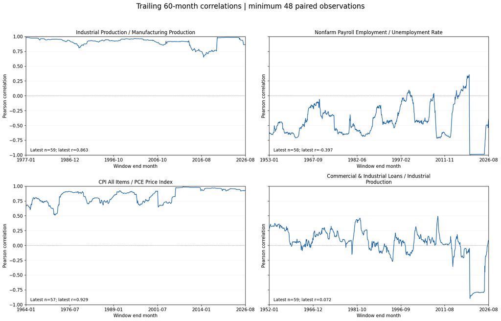

### Latest rolling matrix

Every cell ends in the same calendar month but can have a different paired sample count. Grey cells are unavailable; the diagonal is suppressed because self-correlation is not informative.

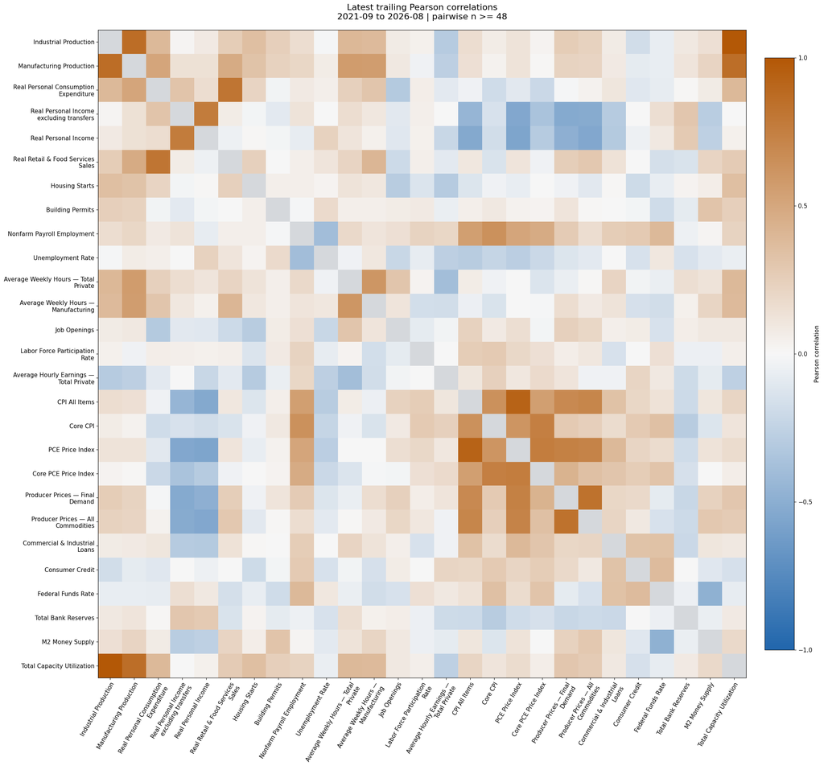

## Checks & Takeaways

- **Monthly series:** 27

- **Pair paths:** 351

- **Window months:** 60

- **Minimum paired observations:** 48

- **Defined rolling estimates:** 189286

- **Latest window:** 2021-09 to 2026-08

- **Pairs defined in latest window:** 351

- **Independently checked windows:** 1053

- **Interpretation:** Changes in rolling association are descriptive; overlapping windows are not independent evidence of regimes or predictability.

```
Input hashes verified unchanged. Exports: C:\Users\HYPE AMD\Desktop\CHronoZ-Economic-Modelling\outputs\rolling_correlation
```